## What is Epigenomics?

What makes them differently?

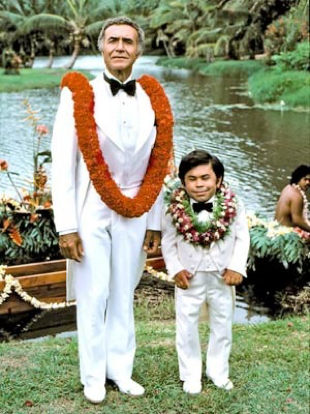

Much human variation is due to difference in ~ 6 million DNA base pairs (0.1 % of genome)

## What is Epigenomics?

What makes them different?

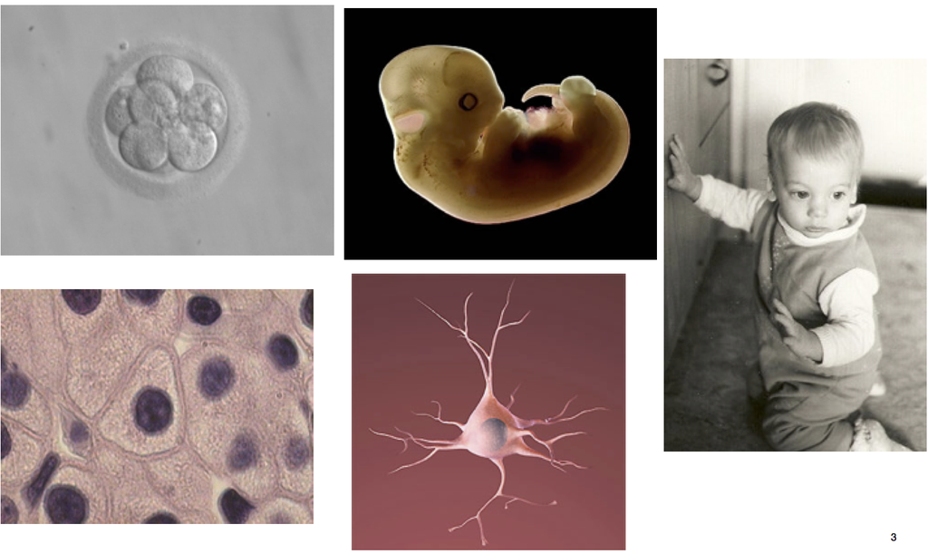

Same genome is **expressed** differently during different **stages** and in different **tissues**.

## What is Epigenomics?

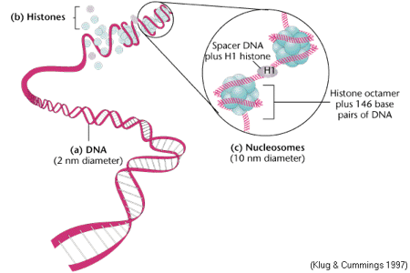

DNA is packed, making parts inaccessible, and this packing is **dynamic**!

## What is Epigenomics?

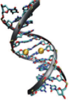

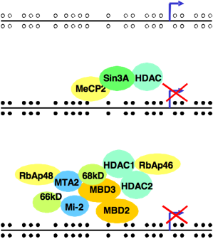

DNA methylation is a chemical modification of DNA, regulates *gene expression*.

## Our motivation

Measuring DNA methylation and understanding role in expression regulation in solid tumors

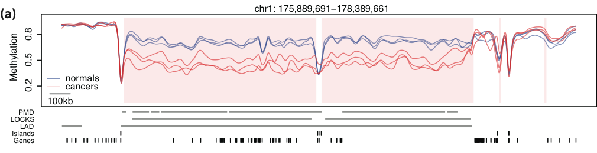

Large blocks of *hypo-methylation* (sometimes Mbps long) in colon cancer

- **Hansen, et al., *Nat. Genetics*, 2011**
- Corrada Bravo, et al., *BMC Bioinformatics*, 2012
- Timp, et al., *Genome Medicine*, 2014
- Dinalankara and Corrada Bravo, *Cancer Informatics*, in press.

## Our motivation

Measuring DNA methylation and understanding role in expression regulation in solid tumors

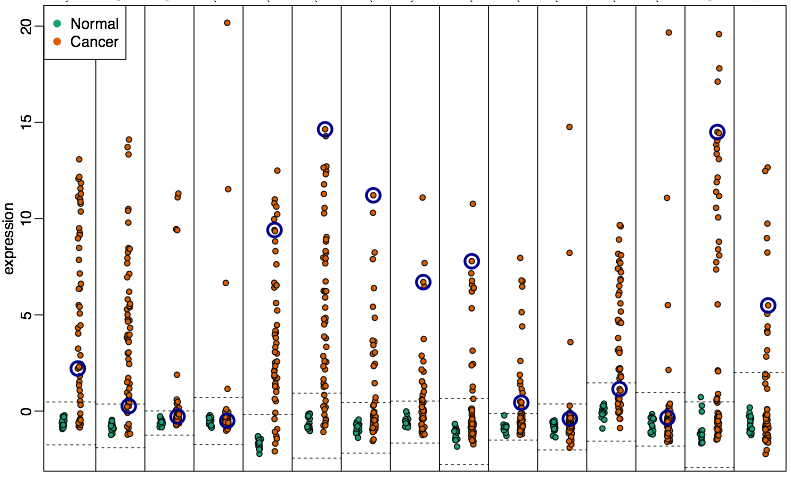

Genes with *hyper-variable* expression in colon cancer are enriched within these blocks.

- **Hansen, et al., *Nat. Genetics*, 2011**
- Corrada Bravo, et al., *BMC Bioinformatics*, 2012
- Timp, et al., *Genome Medicine*, 2014
- Dinalankara and Corrada Bravo, *Cancer Informatics*, in press.

## Our motivation

Measuring DNA methylation and understanding role in expression regulation in solid tumors

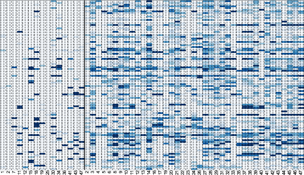

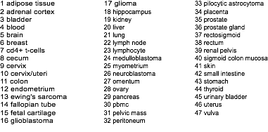

Genes with *consistent hyper-variable expression* across tumors are tissue-specific.

- Hansen, et al., *Nat. Genetics*, 2011
- **Corrada Bravo, et al., *BMC Bioinformatics*, 2012**
- Timp, et al., *Genome Medicine*, 2014
- Dinalankara and Corrada Bravo, *Cancer Informatics*, in press.